# Avaliação dos Programas de Pós-graduação Engenharia Biomédica, Engenharia de Sistemas Eletrônicos e de Automação, Engenharia Elétrica P7 e Engenharia Elétrica P8 e dos Currículos dos Professores e Pes

# VII - Modelagem

Após a realização da limpeza e da preparação dos dados, a ferramenta que será utilizada para modelagem será computacional, para fins de visualização gráfica dos dados obtidos a partir dos dataframes criados.

# VIII - Avaliação

A avaliação será feita de forma gráfica, sendo estes gráficos exibidos a seguir:

#### Engenharia Biomédica

Quantidade de orientações feitas por ano:

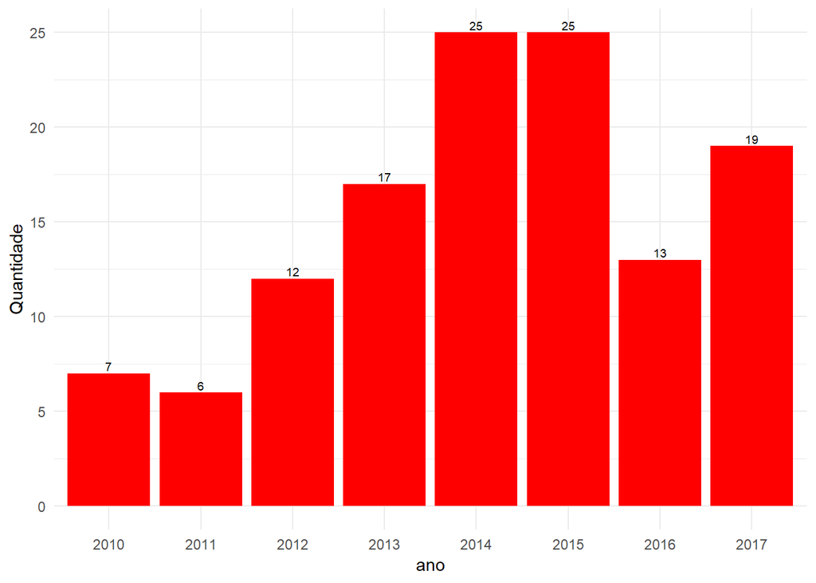

```r
unb.adv.biomed.df %>%
group_by(ano) %>%
summarise(Quantidade = n()) %>%
ggplot(aes(x = ano, y = Quantidade)) +
geom_bar(position = "stack",stat = "identity", fill = "red")+
geom_text(aes(label=Quantidade), vjust=-0.3, size=2.5)+
theme_minimal()
```

Quantidade de orientações separadas por tipo de publicação:

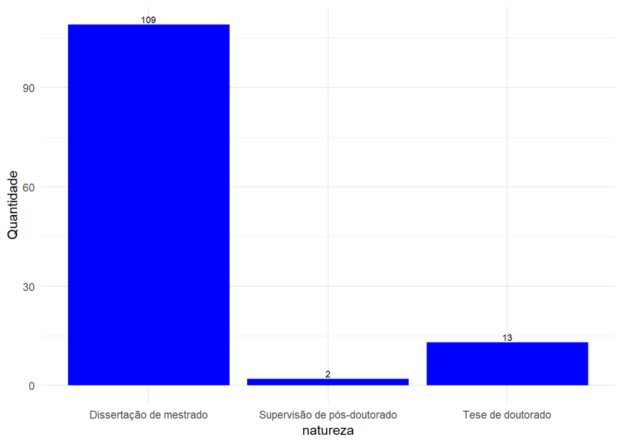

```r
unb.adv.biomed.df %>%
group_by(natureza) %>%
summarise(Quantidade = n()) %>%
ggplot(aes(x = natureza, y = Quantidade)) +
geom_bar(position = "stack",stat = "identity", fill = "blue")+
geom_text(aes(label=Quantidade), vjust=-0.3, size=2.5)+
theme_minimal()
```

Cursos mais presentes:

```r
cursos_d5
```

```
##
##                              Engenharia Elétrica
##                                               77
##                              ENGENHARIA ELÉTRICA
##                                               55
## Programa de Pós-Graduação em Engenharia Elétrica
##                                               12
##                  Mestrado em Engenharia Elétrica
##                                                7
##                 Doutorado em Engenharia Elétrica
##                                                4
```

```r
pie(cursos_d5,clockwise=F,main="Cursos mais presentes")
```

[output not shown]

Quantidade de bolsistas e não bolsistas:

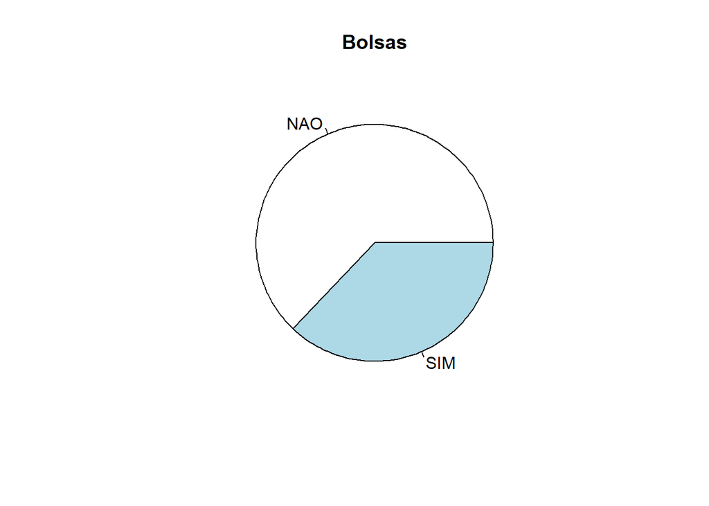

```r
pie(table(unb.adv.biomed.df$bolsa),main="Bolsas")
```

Quantidade de publicações feitas por ano:

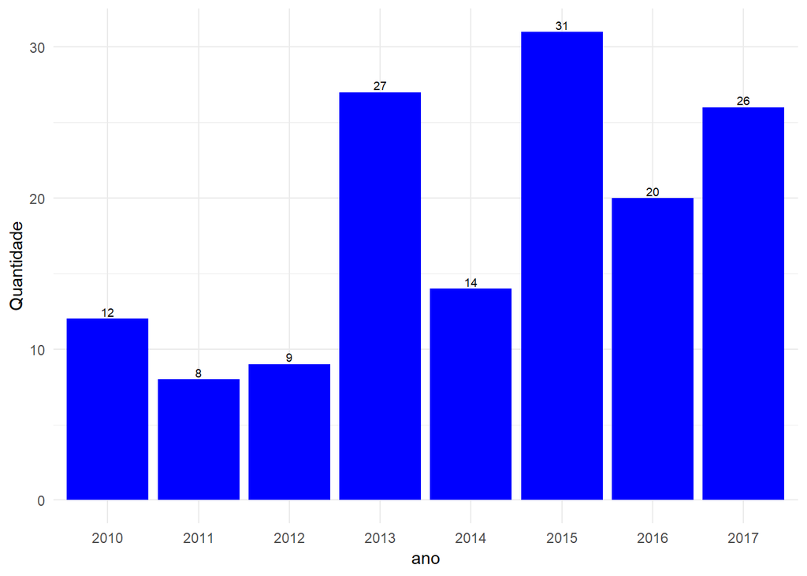

```r
unb.pub.biomed.df %>%
group_by(ano) %>%
summarise(Quantidade = n()) %>%
ggplot(aes(x = ano, y = Quantidade)) +
geom_bar(position = "stack",stat = "identity", fill = "blue")+
geom_text(aes(label=Quantidade), vjust=-0.3, size=2.5)+
theme_minimal()
```

Periódicos com mais publicações:

```r
d <- table(unb.pub.biomed.df$periodico)
head(sort(d,decreasing = TRUE),n=5)
```

```
##
##         Revista Brasileira de Engenharia Biomédica (Impresso)
##                                                             7
## Global Journal of Engineering Science and Research Management
##                                                             6
##                        Biomedical Engineering Online (Online)
##                                                             4
##               Revista Brasileira de Ensino de Física (Online)
##                                                             4
##           Revista Brasileira de Inovação Tecnologica em Saúde
##                                                             4
```

Autores com mais participações em publicações:

```r
head(sort(table(toupper(unlist(strsplit(unb.pub.biomed.df$autores,";")))),decreasing = TRUE),n=10)
```

```
##
##                          AMORIM, R. G. G.
##                                        17
##                          AMORIM, R. G. G.
##                                        16
##                       MARÃES, V. R. F. S.
##                                        14
##                             BRASIL, L. M.
##                                         7
##                       MARÃES, V. R. F. S.
##                                         7
##                              SILVA, W. B.
##                                         7
##              GOMES, MARÍLIA MIRANDA FORTE
##                                         7
## ROSA, SUÉLIA DE SIQUEIRA RODRIGUES FLEURY
##                                         7
##                           DA ROCHA, A. F.
##                                         6
##              GOMES, MARÍLIA MIRANDA FORTE
##                                         6
```

Vemos que há algumas incoeráncia neste dado acima, isto se dá pela falta de uniformidade dos dados.

Perfis de docentes por senioridade:

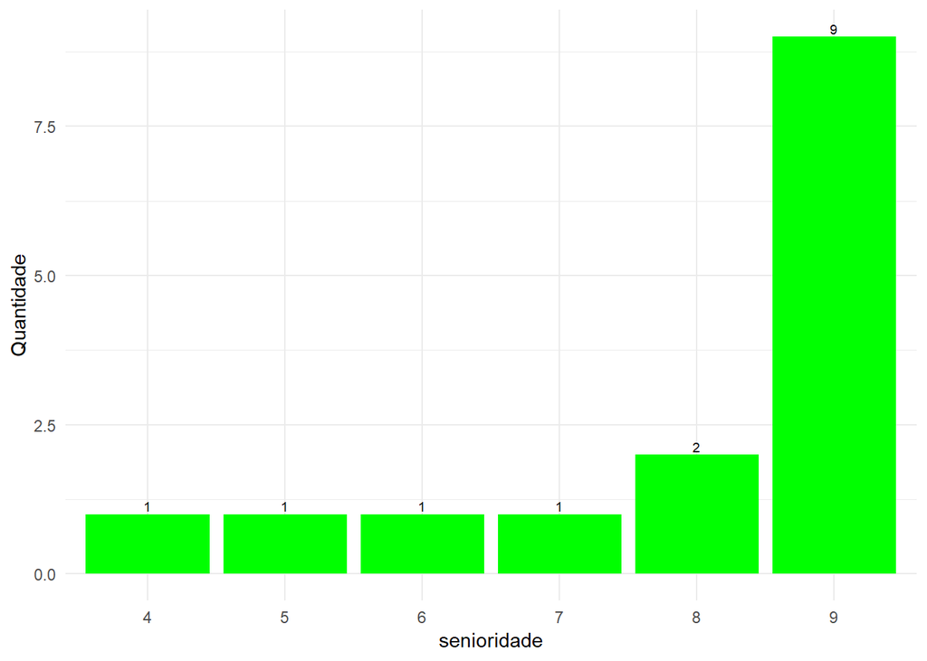

```r
unb.prof.biomed.df %>%
group_by(senioridade) %>%
summarise(Quantidade = n()) %>%
ggplot(aes(x = senioridade, y = Quantidade)) +
geom_bar(position = "stack",stat = "identity", fill = "green")+
geom_text(aes(label=Quantidade), vjust=-0.3, size=2.5)+
theme_minimal()
```

Quantidade de orientações concluídas no doutorado por professor:

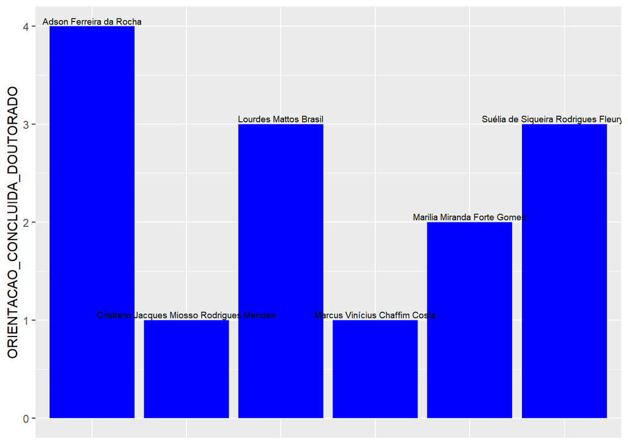

```r
unb.prof.biomed.df %>%
group_by(nome) %>%
filter(!is.na(ORIENTACAO_CONCLUIDA_DOUTORADO))%>%
ggplot(aes(x = nome, y = ORIENTACAO_CONCLUIDA_DOUTORADO)) +
geom_bar(position = "stack",stat = "identity", fill = "blue")+
geom_text(aes(label=nome), vjust=-0.3, size=2.5)+
theme(axis.title.x=element_blank(),
        axis.text.x=element_blank(),
        axis.ticks.x=element_blank())
```

Quantidade de orientações concluídas no mestrado por professor:

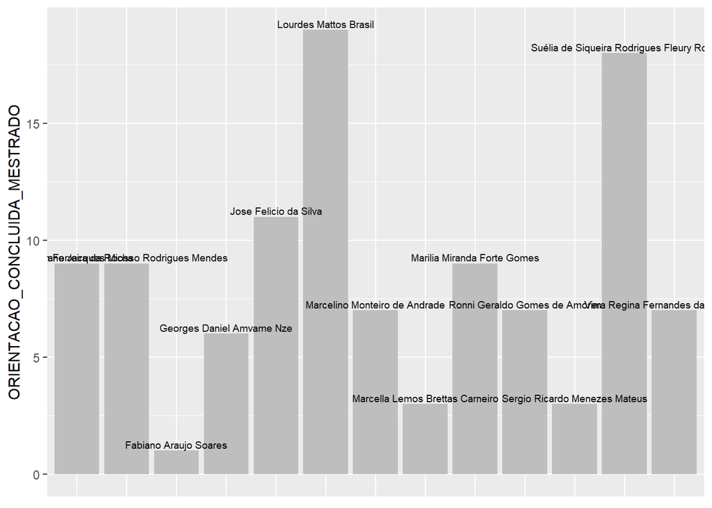

```r
unb.prof.biomed.df %>%
group_by(nome) %>%
filter(!is.na(ORIENTACAO_CONCLUIDA_MESTRADO ))%>%
ggplot(aes(x = nome, y = ORIENTACAO_CONCLUIDA_MESTRADO)) +
geom_bar(position = "stack",stat = "identity", fill = "gray")+
geom_text(aes(label=nome), vjust=-0.3, size=2.5)+
theme(axis.title.x=element_blank(),
        axis.text.x=element_blank(),
        axis.ticks.x=element_blank())
```

Quantidade de orientações concluídas no pós-doutorado por professor:

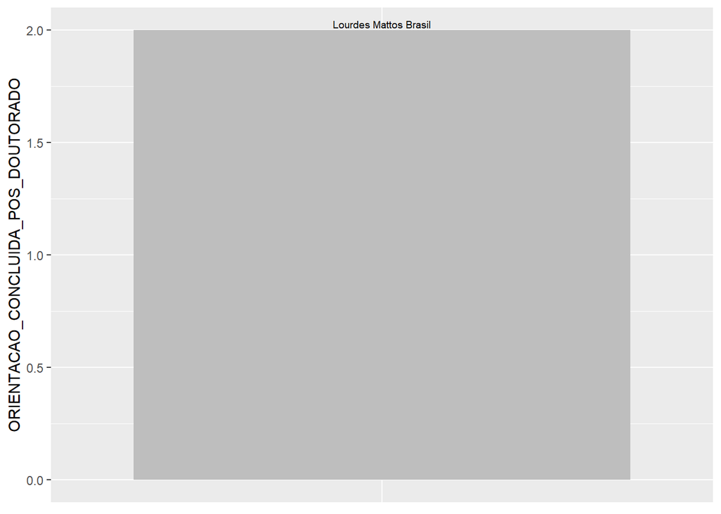

```r
unb.prof.biomed.df %>%
group_by(nome) %>%
filter(!is.na(ORIENTACAO_CONCLUIDA_POS_DOUTORADO))%>%
ggplot(aes(x = nome, y = ORIENTACAO_CONCLUIDA_POS_DOUTORADO)) +
geom_bar(position = "stack",stat = "identity", fill = "gray")+
geom_text(aes(label=nome), vjust=-0.3, size=2.5)+
theme(axis.title.x=element_blank(),
        axis.text.x=element_blank(),
        axis.ticks.x=element_blank())
```

Quantidade de orientações concluídas em outros tipos por professor:

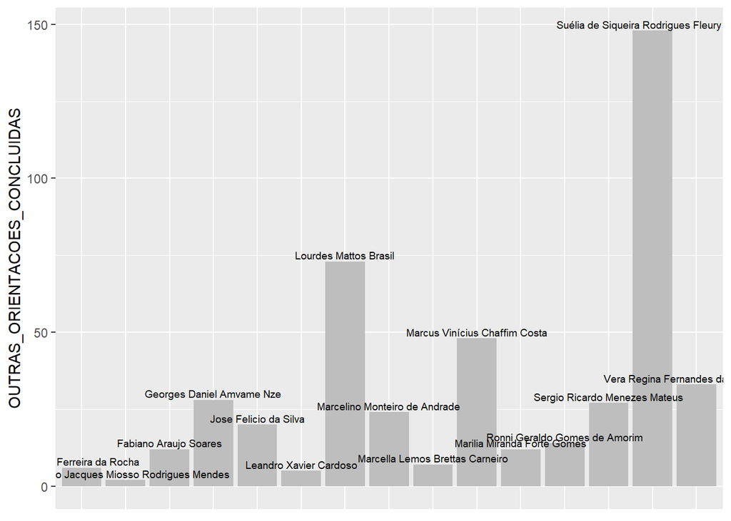

```r
unb.prof.biomed.df %>%
group_by(nome) %>%
filter(!is.na(OUTRAS_ORIENTACOES_CONCLUIDAS))%>%
ggplot(aes(x = nome, y = OUTRAS_ORIENTACOES_CONCLUIDAS)) +
geom_bar(position = "stack",stat = "identity", fill = "gray")+
geom_text(aes(label=nome), vjust=-0.3, size=2.5)+
theme(axis.title.x=element_blank(),
        axis.text.x=element_blank(),
        axis.ticks.x=element_blank())
```

Quantidade de eventos por professor:

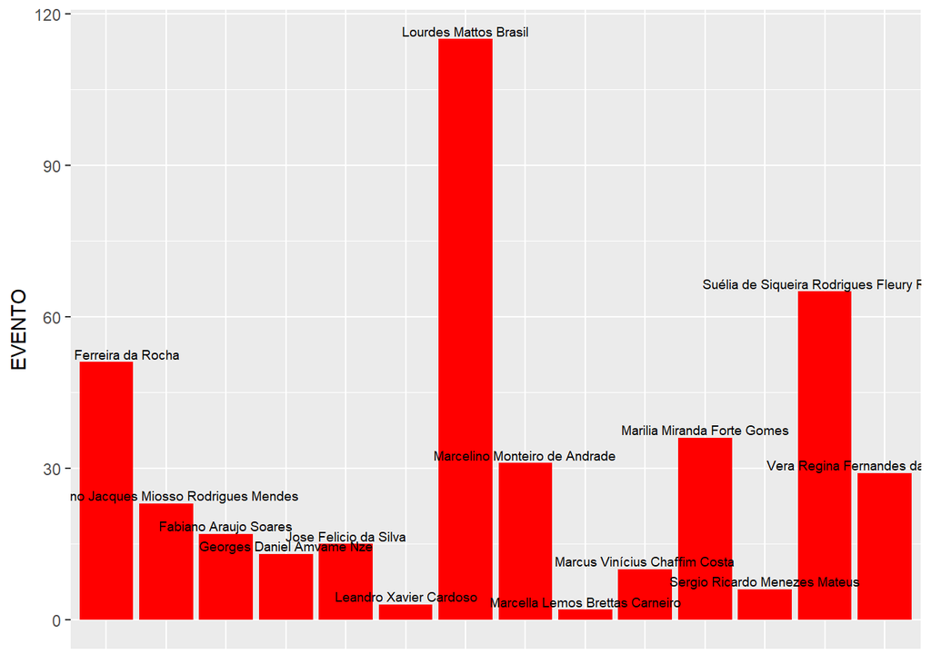

```r
unb.prof.biomed.df %>%
group_by(nome) %>%
filter(!is.na(EVENTO))%>%
ggplot(aes(x = nome, y = EVENTO)) +
geom_bar(position = "stack",stat = "identity", fill = "red")+
geom_text(aes(label=nome), vjust=-0.3, size=2.5)+
theme(axis.title.x=element_blank(),
        axis.text.x=element_blank(),
        axis.ticks.x=element_blank())
```

Quantidade de periódicos por professor:

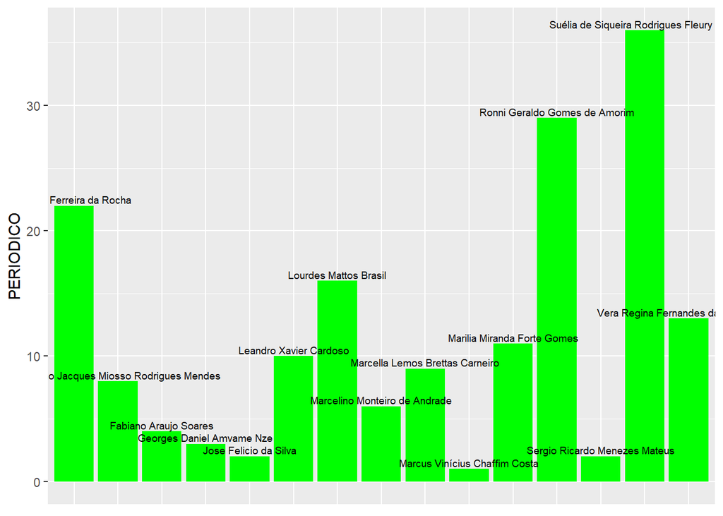

```r
unb.prof.biomed.df %>%
group_by(nome) %>%
filter(!is.na(PERIODICO))%>%
ggplot(aes(x = nome, y = PERIODICO)) +
geom_bar(position = "stack",stat = "identity", fill = "green")+
geom_text(aes(label=nome), vjust=-0.3, size=2.5)+
theme(axis.title.x=element_blank(),
        axis.text.x=element_blank(),
        axis.ticks.x=element_blank())
```

Quantidade de livros por professor:

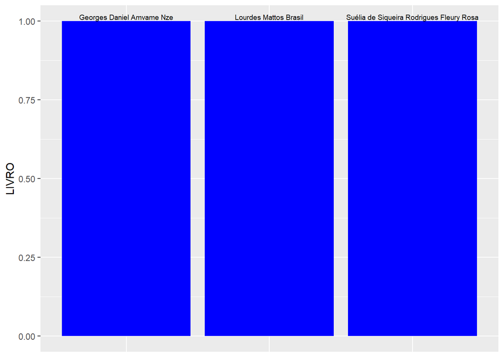

```r
unb.prof.biomed.df %>%
group_by(nome) %>%
filter(!is.na(LIVRO))%>%
ggplot(aes(x = nome, y = LIVRO)) +
geom_bar(position = "stack",stat = "identity", fill = "blue")+
geom_text(aes(label=nome), vjust=-0.3, size=2.5)+
theme(axis.title.x=element_blank(),
        axis.text.x=element_blank(),
        axis.ticks.x=element_blank())
```

Quantidade de texto em jornais por professor:

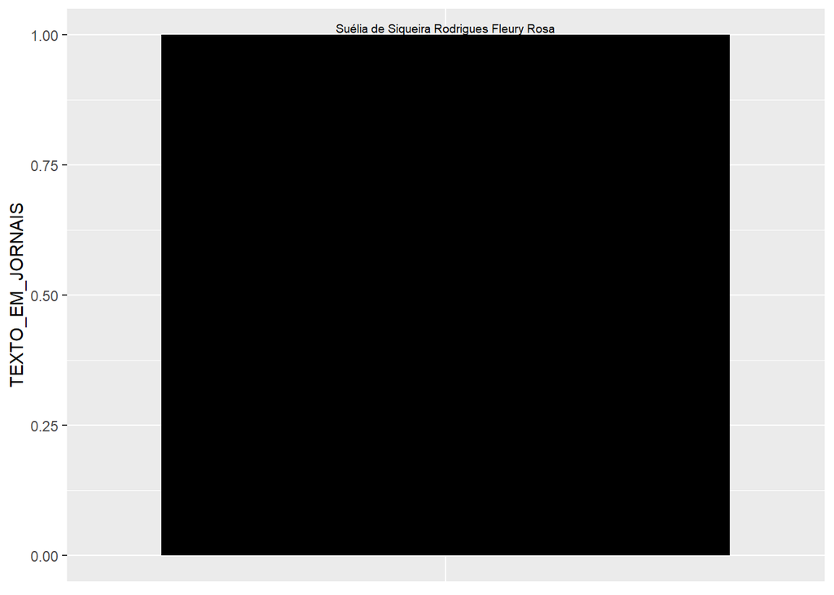

```r
unb.prof.biomed.df %>%
group_by(nome) %>%
filter(!is.na(TEXTO_EM_JORNAIS))%>%
ggplot(aes(x = nome, y = TEXTO_EM_JORNAIS)) +
geom_bar(position = "stack",stat = "identity", fill = "black")+
geom_text(aes(label=nome), vjust=-0.3, size=2.5)+
theme(axis.title.x=element_blank(),
        axis.text.x=element_blank(),
        axis.ticks.x=element_blank())
```

Relações entre professores:

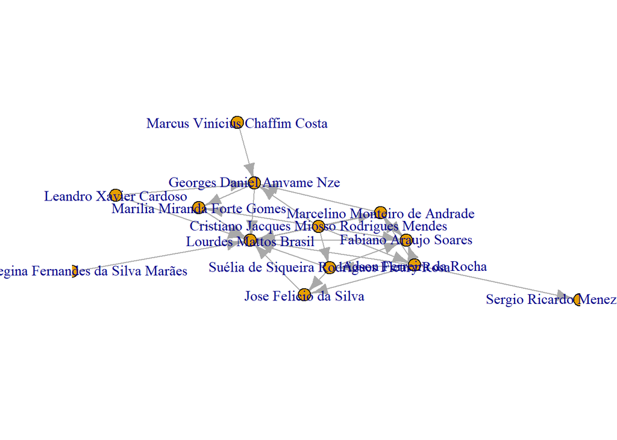

```r
list <- c(rbind(unb.graph.biomed$links$source,unb.graph.biomed$links$target))
idx <- match(list, unb.graph.biomed$nodes$id)
names <- unb.graph.biomed$nodes$properties$name
graph_names <- names[idx]
g <-graph(graph_names, directed=TRUE)
plot(g, layout = layout_(g, nicely()),
     edge.width = 1,
     edge.arrow.width = 1,
     vertex.size = 5,
     edge.arrow.size = 1,
     vertex.size2 = 3,
     vertex.label.cex = 1,
     asp = 0.35,
     margin = -0.1)
```

Nuvem de palavras baseadas no resumo do currículo dos professores:

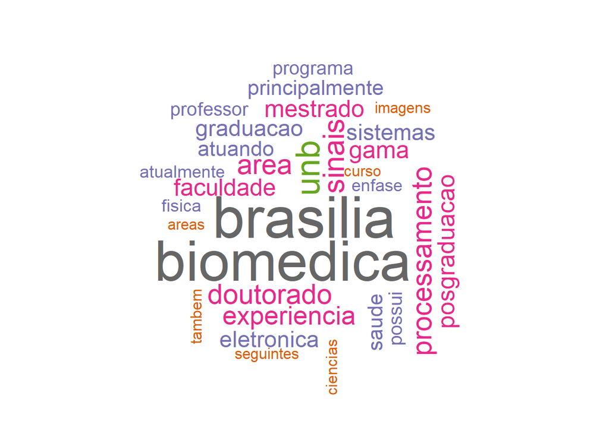

```r
unb.prof.biomed.df$resumo_cv <- iconv(unb.prof.biomed.df$resumo_cv,from="UTF-8", to = "ASCII//TRANSLIT")
df_wc <- data.frame(doc_id = unb.prof.biomed.df$idLattes, text = unb.prof.biomed.df$resumo_cv, stringsAsFactors = FALSE )
docs <- Corpus(DataframeSource(df_wc))
docs <- tm_map(docs, content_transformer(tolower))
docs <- tm_map(docs, removeNumbers)
docs <- tm_map(docs, removeWords, stopwords("pt"))
docs <- tm_map(docs, removeWords, c("universidade", "federal","eletrica","posgraduacao","engenheiro","engenharia"))
docs <- tm_map(docs, removePunctuation)
docs <- tm_map(docs, stripWhitespace)
dtm <- TermDocumentMatrix(docs)
m <- as.matrix(dtm)
v <- sort(rowSums(m),decreasing=TRUE)
d <- data.frame(word = names(v),freq=v)
set.seed(1234)
wordcloud(words =(d$word), freq = d$freq, min.freq = 3,
          max.words=30,scale = c(4, 0.2), random.order=FALSE, rot.per=0.35,
          colors=brewer.pal(8, "Dark2"))
```

Nuvem de palavras baseadas no título das orientações:

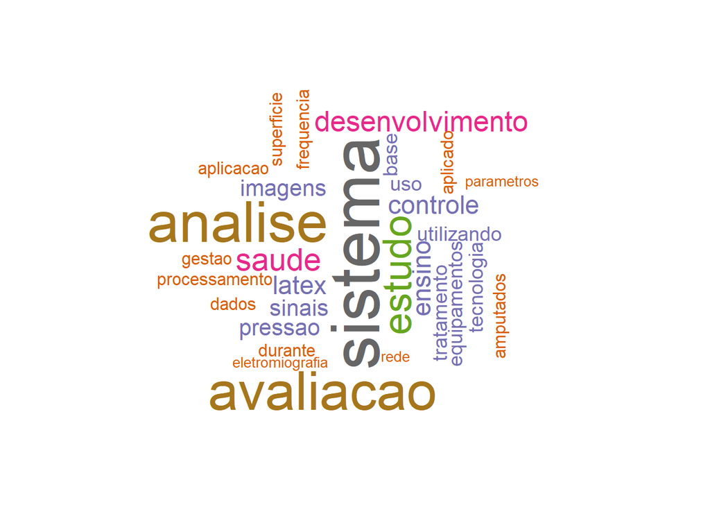

```r
unb.adv.biomed.df$titulo <- iconv(unb.adv.biomed.df$titulo,from="UTF-8", to = "ASCII//TRANSLIT")
df_wc <- data.frame(doc_id = unb.adv.biomed.df$idLattes1, text = unb.adv.biomed.df$titulo, stringsAsFactors = FALSE )
docs <- Corpus(DataframeSource(df_wc))
docs <- tm_map(docs, content_transformer(tolower))
docs <- tm_map(docs, removeNumbers)
docs <- tm_map(docs, removeWords, stopwords("pt"))
docs <- tm_map(docs, removeWords, stopwords("english"))
docs <- tm_map(docs, removeWords, c("universidade", "federal","eletrica","posgraduacao","engenheiro","engenharia"))
docs <- tm_map(docs, removePunctuation)
docs <- tm_map(docs, stripWhitespace)
dtm <- TermDocumentMatrix(docs)
m <- as.matrix(dtm)
v <- sort(rowSums(m),decreasing=TRUE)
d <- data.frame(word = names(v),freq=v)
set.seed(1234)
wordcloud(words =(d$word), freq = d$freq, min.freq = 3,
          max.words=30,scale = c(4, 0.2), random.order=FALSE, rot.per=0.35,
          colors=brewer.pal(8, "Dark2"))
```

#### Engenharia de Sistemas Eletrônicos e de Automação

Quantidade de orientações feitas por ano:

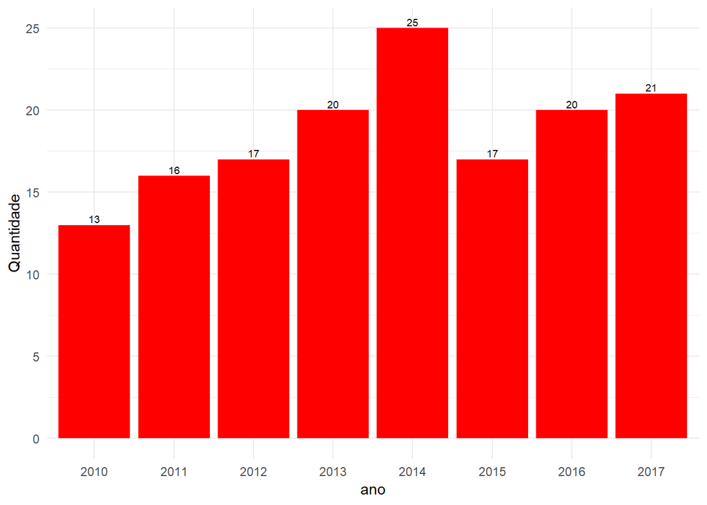

```r
unb.adv.auto.df %>%
group_by(ano) %>%
summarise(Quantidade = n()) %>%
ggplot(aes(x = ano, y = Quantidade)) +
geom_bar(position = "stack",stat = "identity", fill = "red")+
geom_text(aes(label=Quantidade), vjust=-0.3, size=2.5)+
theme_minimal()
```

Quantidade de orientações separadas por tipo de publicação:

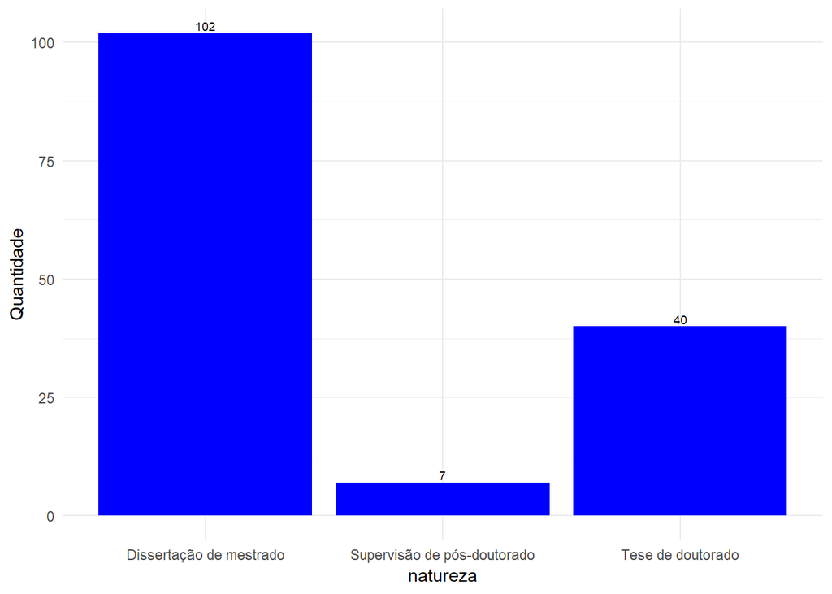

```r
unb.adv.auto.df %>%
group_by(natureza) %>%
summarise(Quantidade = n()) %>%
ggplot(aes(x = natureza, y = Quantidade)) +
geom_bar(position = "stack",stat = "identity", fill = "blue")+
geom_text(aes(label=Quantidade), vjust=-0.3, size=2.5)+
theme_minimal()
```

Cursos mais presentes:

```r
cursos_d5
```

```
##
##                              Engenharia Elétrica
##                                               77
##                              ENGENHARIA ELÉTRICA
##                                               55
## Programa de Pós-Graduação em Engenharia Elétrica
##                                               12
##                  Mestrado em Engenharia Elétrica
##                                                7
##                 Doutorado em Engenharia Elétrica
##                                                4
```

```r
pie(cursos_d5,clockwise=F,main="Cursos mais presentes")
```

[output not shown]

Quantidade de bolsistas e não bolsistas:

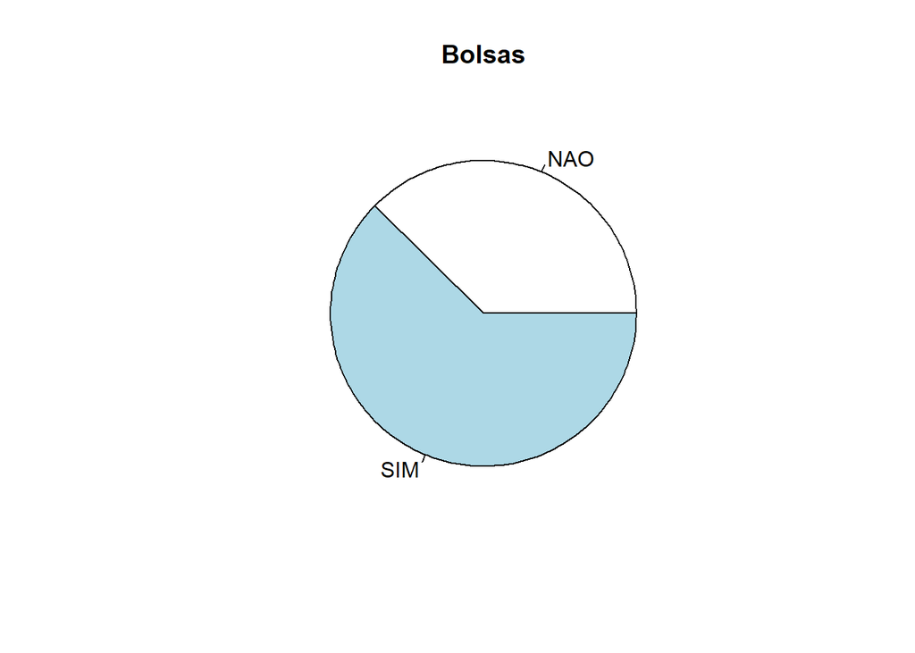

```r
pie(table(unb.adv.auto.df$bolsa),main="Bolsas")
```

Quantidade de publicações feitas por ano:

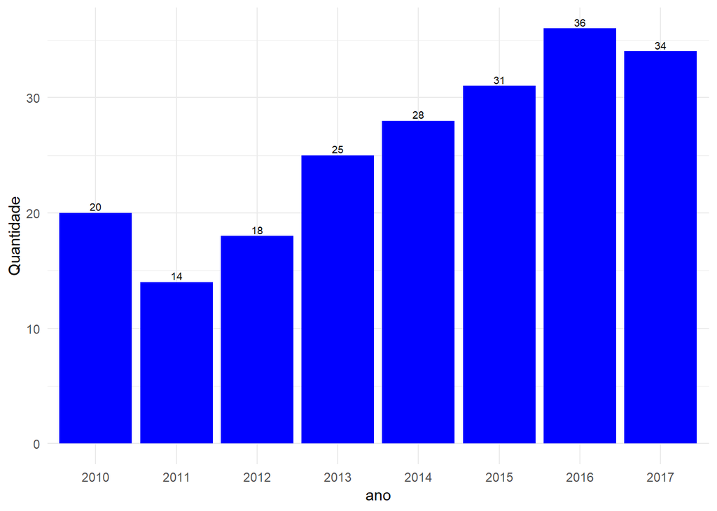

```r
unb.pub.auto.df %>%
group_by(ano) %>%
summarise(Quantidade = n()) %>%
ggplot(aes(x = ano, y = Quantidade)) +
geom_bar(position = "stack",stat = "identity", fill = "blue")+
geom_text(aes(label=Quantidade), vjust=-0.3, size=2.5)+
theme_minimal()
```

Periódicos com mais publicações:

```r
d <- table(unb.pub.auto.df$periodico)
head(sort(d,decreasing = TRUE),n=5)
```

```
##
## Revista Brasileira de Engenharia Biomédica (Impresso)
##                                                     7
##                        IEEE Signal Processing Letters
##                                                     5
## Journal of Control, Automation and Electrical Systems
##                                                     5
##                                   Electronics Letters
##                                                     4
## INTERNATIONAL JOURNAL OF ROBUST AND NONLINEAR CONTROL
##                                                     4
```

Autores com mais participações em publicações:

```r
head(sort(table(toupper(unlist(strsplit(unb.pub.auto.df$autores,";")))),decreasing = TRUE),n=10)
```

```
##
##                          BOTTARO, MARTIM
##                                       12
##                          ISHIHARA, J. Y.
##                                       12
##                      DE QUEIROZ, RICARDO
##                                       12
##                   DE QUEIROZ, RICARDO L.
##                                       11
##                            CLAUS, MARTIN
##                                       10
##                          PERES, P. L. D.
##                                       10
##                            QUEIROZ, R.L.
##                                       10
##                        DE QUEIROZ, R. L.
##                                        9
##                        ISHIHARA, JOÃO Y.
##                                        9
##  NASCIMENTO, FRANCISCO ASSIS DE OLIVEIRA
##                                        9
```

Vemos que há algumas incoeráncia neste dado acima, isto se dá pela falta de uniformidade dos dados.

Perfis de docentes por senioridade:

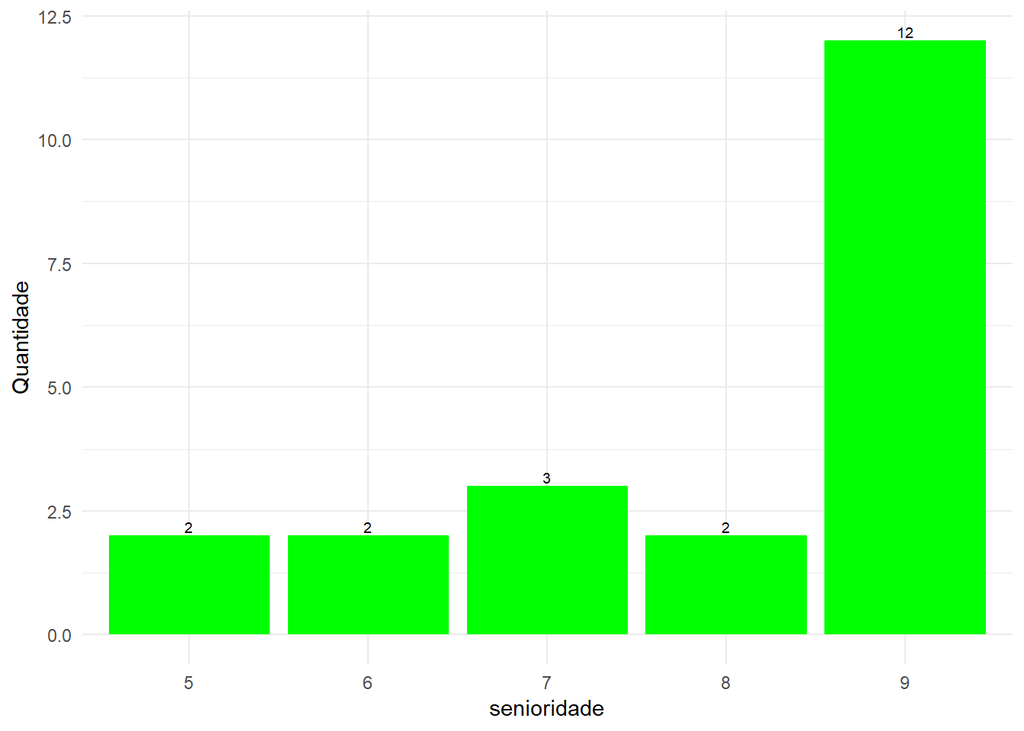

```r
unb.prof.auto.df %>%
group_by(senioridade) %>%
summarise(Quantidade = n()) %>%
ggplot(aes(x = senioridade, y = Quantidade)) +
geom_bar(position = "stack",stat = "identity", fill = "green")+
geom_text(aes(label=Quantidade), vjust=-0.3, size=2.5)+
theme_minimal()
```

Quantidade de orientações concluídas no doutorado por professor:

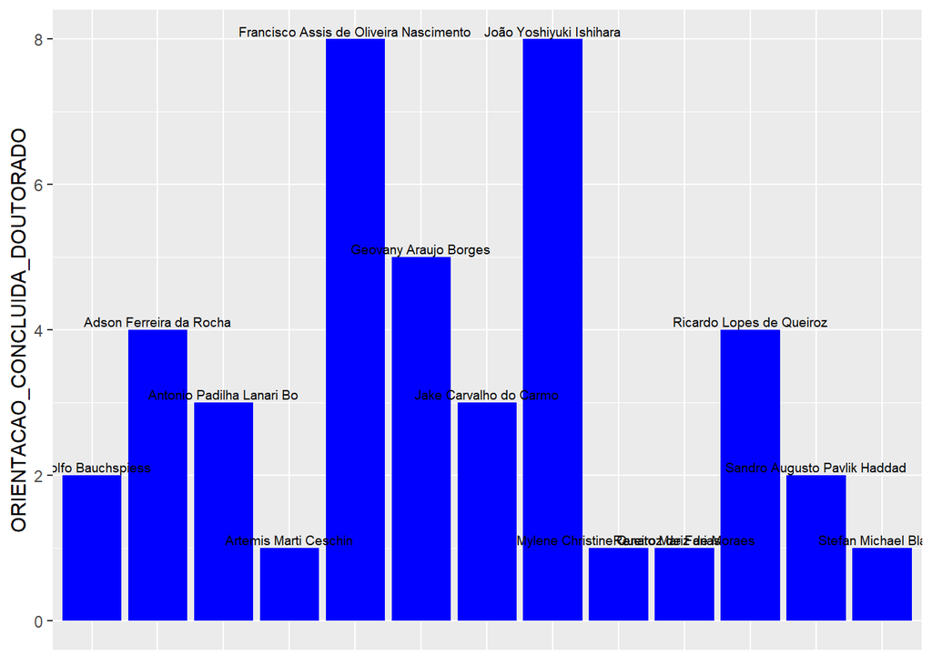

```r
unb.prof.auto.df %>%
group_by(nome) %>%
filter(!is.na(ORIENTACAO_CONCLUIDA_DOUTORADO))%>%
ggplot(aes(x = nome, y = ORIENTACAO_CONCLUIDA_DOUTORADO)) +
geom_bar(position = "stack",stat = "identity", fill = "blue")+
geom_text(aes(label=nome), vjust=-0.3, size=2.5)+
theme(axis.title.x=element_blank(),
        axis.text.x=element_blank(),
        axis.ticks.x=element_blank())
```

Quantidade de orientações concluídas no mestrado por professor:

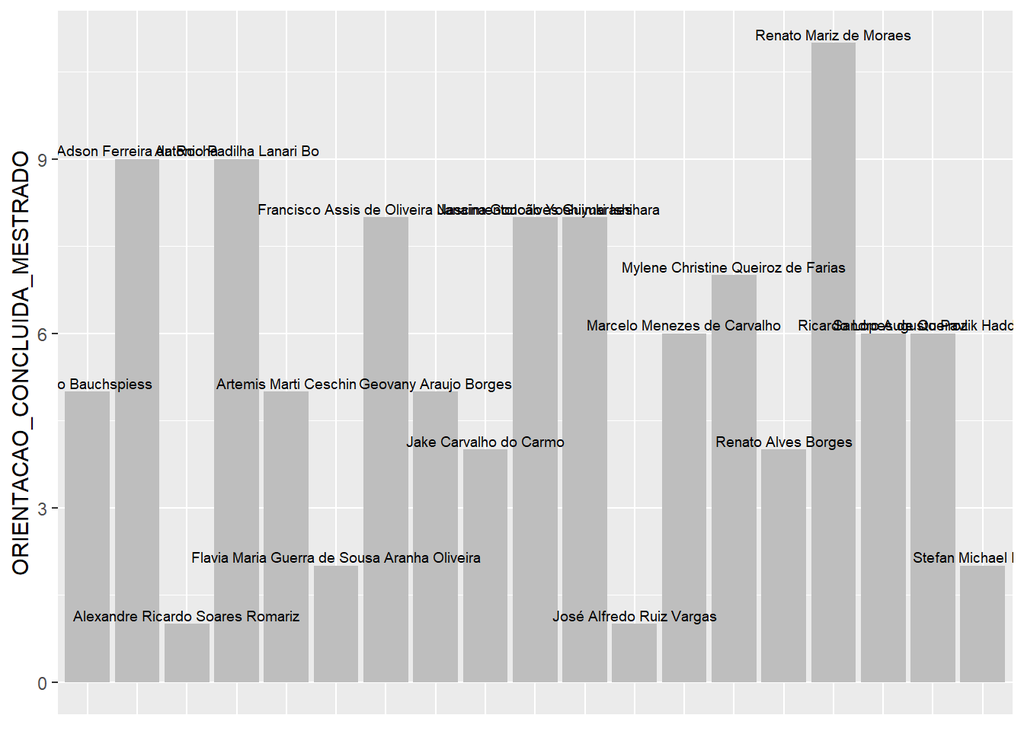

```r
unb.prof.auto.df %>%
group_by(nome) %>%
filter(!is.na(ORIENTACAO_CONCLUIDA_MESTRADO ))%>%
ggplot(aes(x = nome, y = ORIENTACAO_CONCLUIDA_MESTRADO)) +
geom_bar(position = "stack",stat = "identity", fill = "gray")+
geom_text(aes(label=nome), vjust=-0.3, size=2.5)+
theme(axis.title.x=element_blank(),
        axis.text.x=element_blank(),
        axis.ticks.x=element_blank())
```

Quantidade de orientações concluídas no pós-doutorado por professor:

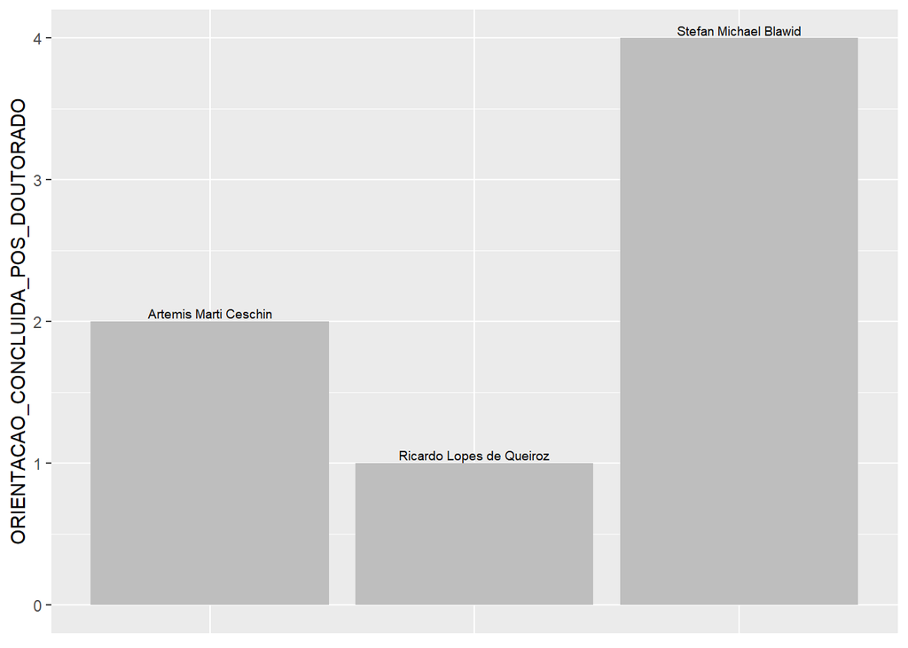

```r
unb.prof.auto.df %>%
group_by(nome) %>%
filter(!is.na(ORIENTACAO_CONCLUIDA_POS_DOUTORADO))%>%
ggplot(aes(x = nome, y = ORIENTACAO_CONCLUIDA_POS_DOUTORADO)) +
geom_bar(position = "stack",stat = "identity", fill = "gray")+
geom_text(aes(label=nome), vjust=-0.3, size=2.5)+
theme(axis.title.x=element_blank(),
        axis.text.x=element_blank(),
        axis.ticks.x=element_blank())
```

Quantidade de orientações concluídas em outros tipos por professor:

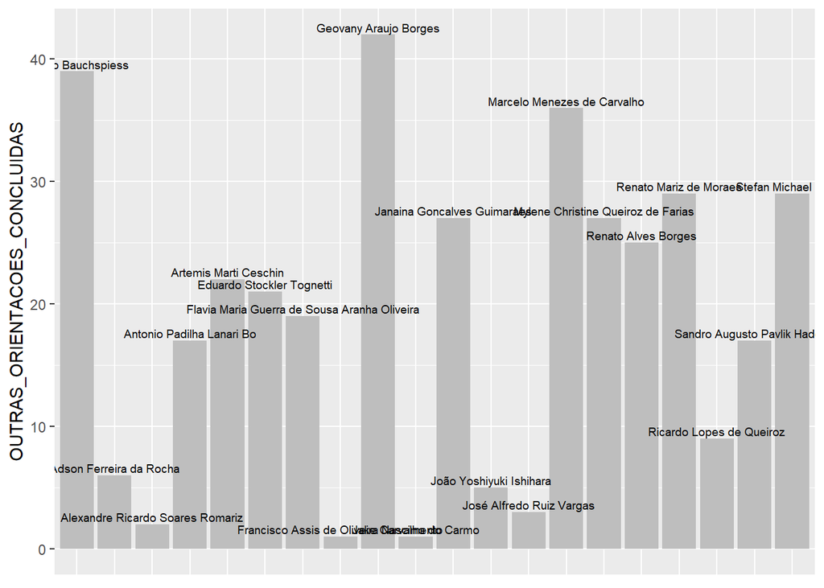

```r
unb.prof.auto.df %>%
group_by(nome) %>%
filter(!is.na(OUTRAS_ORIENTACOES_CONCLUIDAS))%>%
ggplot(aes(x = nome, y = OUTRAS_ORIENTACOES_CONCLUIDAS)) +
geom_bar(position = "stack",stat = "identity", fill = "gray")+
geom_text(aes(label=nome), vjust=-0.3, size=2.5)+
theme(axis.title.x=element_blank(),
        axis.text.x=element_blank(),
        axis.ticks.x=element_blank())
```

Quantidade de eventos por professor:

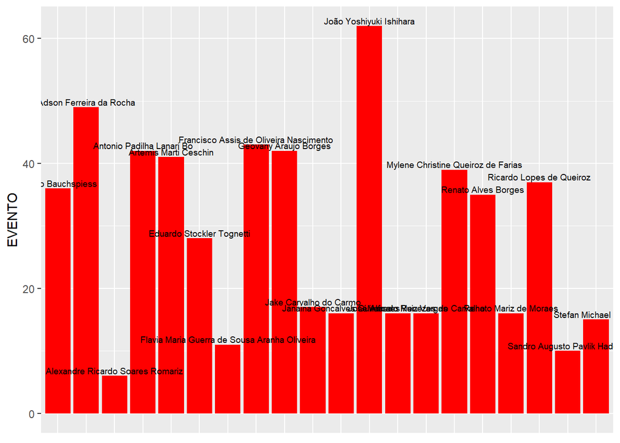

```r
unb.prof.auto.df %>%
group_by(nome) %>%
filter(!is.na(EVENTO))%>%
ggplot(aes(x = nome, y = EVENTO)) +
geom_bar(position = "stack",stat = "identity", fill = "red")+
geom_text(aes(label=nome), vjust=-0.3, size=2.5)+
theme(axis.title.x=element_blank(),
        axis.text.x=element_blank(),
        axis.ticks.x=element_blank())
```

Quantidade de periódicos por professor:

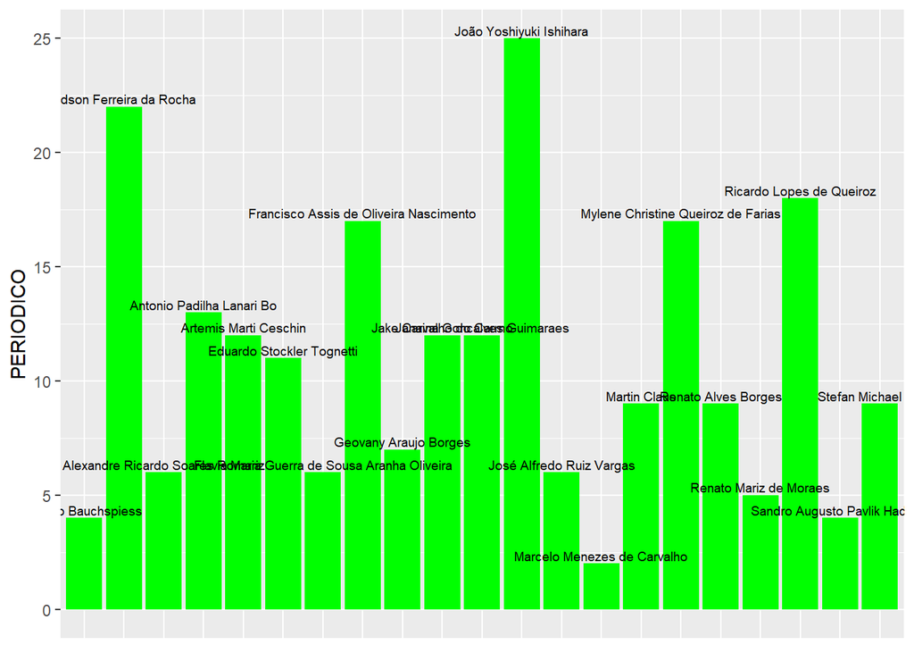

```r
unb.prof.auto.df %>%
group_by(nome) %>%
filter(!is.na(PERIODICO))%>%
ggplot(aes(x = nome, y = PERIODICO)) +
geom_bar(position = "stack",stat = "identity", fill = "green")+
geom_text(aes(label=nome), vjust=-0.3, size=2.5)+
theme(axis.title.x=element_blank(),
        axis.text.x=element_blank(),
        axis.ticks.x=element_blank())
```

Quantidade de livros por professor:

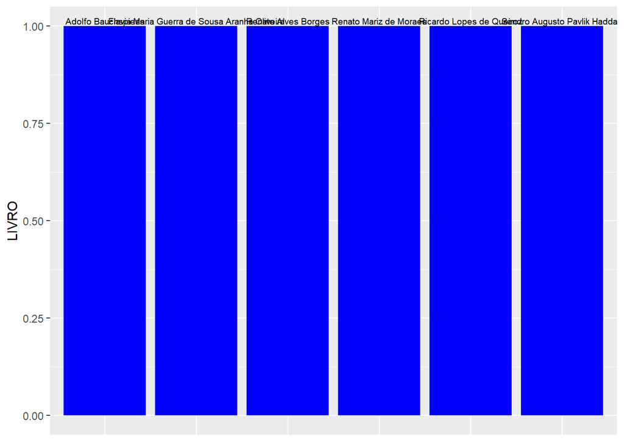

```r
unb.prof.auto.df %>%
group_by(nome) %>%
filter(!is.na(LIVRO))%>%
ggplot(aes(x = nome, y = LIVRO)) +
geom_bar(position = "stack",stat = "identity", fill = "blue")+
geom_text(aes(label=nome), vjust=-0.3, size=2.5)+
theme(axis.title.x=element_blank(),
        axis.text.x=element_blank(),
        axis.ticks.x=element_blank())
```